# Project 6: Randomization and Matching

# Introduction

In this project, you will explore the question of whether college education causally affects political participation. Specifically, you will use replication data from by former Berkeley PhD students John Henderson and Sara Chatfield. Their paper is itself a replication study of by Cindy Kam and Carl Palmer. In their original 2008 study, Kam and Palmer argue that college education has no effect on later political participation, and use the propensity score matching to show that pre-college political activity drives selection into college and later political participation. Henderson and Chatfield in their 2011 paper argue that the use of the propensity score matching in this context is inappropriate because of the bias that arises from small changes in the choice of variables used to model the propensity score. They use (at that point a new method), which uses an approach similar to optimal matching to optimize Mahalanobis distance weights. Even with genetic matching, they find that balance remains elusive however, thus leaving open the question of whether education causes political participation.

You will use these data and debates to investigate the benefits and pitfalls associated with matching methods. Replication code for these papers is available online, but as you’ll see, a lot has changed in the last decade or so of data science! Throughout the assignment, use tools we introduced in lab from the and the packages. Specifically, try to use dplyr, tidyr, purrr, stringr, and ggplot instead of base R functions. While there are other matching software libraries available, MatchIt tends to be the most up to date and allows for consistent syntax.

# Data

Otherwise, we also have covariates measured for survey responses to various questions about political attitudes. We have covariates measured for the students in the baseline year, covariates for their parents in the baseline year, and covariates from follow-up surveys. . In general, post-treatment covariates will be clear from the name (i.e. student_1973Married indicates whether the student was married in the 1973 survey). Be mindful that the baseline covariates were all measured in 1965, the treatment occurred between 1965 and 1973, and the outcomes are from 1973 and beyond. We will distribute the Appendix from Henderson and Chatfield that describes the covariates they used, but please reach out with any questions if you have questions about what a particular variable means.

```r
# Load tidyverse and MatchIt
# Feel free to load other libraries as you wish
library(tidyverse)
library(MatchIt)
```

```r
library(ggplot2)

set.seed(8)
# Load ypsps data
ypsps <- read.csv('data/ypsps.csv')
head(ypsps)
```

|  | interviewid | college | student_vote | student_meeting | student_other | student_button | student_money | student_communicate | student_demonstrate | student_community | student_ppnscal | student_PubAff | student_Newspaper | student_Radio | student_TV | student_Magazine | student_FamTalk | student_FrTalk | student_AdultTalk | student_PID | student_SPID | student_GovtOpinion | student_GovtCrook | student_GovtWaste | student_TrGovt | student_GovtSmart | student_Govt4All | student_Cynic | student_LifeWish | … |
| --- | --- | --- | --- | --- | --- | --- | --- | --- | --- | --- | --- | --- | --- | --- | --- | --- | --- | --- | --- | --- | --- | --- | --- | --- | --- | --- | --- | --- | --- | --- |
| 1 | 1 | 1 | 1 | 0 | 0 | 0 | 0 | 0 | 1 | 1 | 3 | 1 | 1 | 1 | 3 | 1 | 1 | 2 | 4 | 2 | 2 | 2 | 2 | 2 | 2 | 1 | 2 | 3 | 1 | … |
| 2 | 2 | 1 | 1 | 1 | 1 | 1 | 0 | 1 | 1 | 1 | 7 | 1 | 2 | 5 | 2 | 1 | 1 | 1 | 2 | 1 | 3 | 1 | 2 | 3 | 2 | 1 | 3 | 3 | 1 | … |
| 3 | 3 | 1 | 1 | 0 | 0 | 1 | 0 | 0 | 0 | 0 | 2 | 1 | 2 | 1 | 3 | 1 | 1 | 2 | 3 | 6 | 2 | 1 | 2 | 2 | 2 | 3 | 2 | 6 | 1 | … |
| 4 | 4 | 0 | 0 | 0 | 0 | 0 | 0 | 1 | 0 | 1 | 2 | 1 | 2 | 1 | 5 | 1 | 1 | 1 | 1 | 3 | 1 | 1 | 2 | 2 | 2 | 1 | 3 | 3 | 3 | … |
| 5 | 5 | 1 | 1 | 1 | 0 | 0 | 0 | 1 | 0 | 0 | 3 | 1 | 1 | 1 | 2 | 1 | 1 | 1 | 2 | 1 | 3 | 1 | 2 | 2 | 1 | 1 | 3 | 2 | 1 | … |
| 6 | 6 | 1 | 1 | 0 | 0 | 0 | 1 | 0 | 0 | 0 | 2 | 0 | 2 | 1 | 5 | 3 | 4 | 4 | 4 | 6 | 2 | 3 | 2 | 2 | 1 | 1 | 3 | 2 | 1 | … |

# Randomization

Matching is usually used in observational studies to to approximate random assignment to treatment. But could it be useful even in randomized studies? To explore the question do the following:

1. Generate a vector that randomly assigns each unit to either treatment or control item Choose a baseline covariate (for either the student or parent). A binary covariate is probably best for this exercise.
2. Visualize the distribution of the covariate by treatment/control condition. Are treatment and control balanced on this covariate?

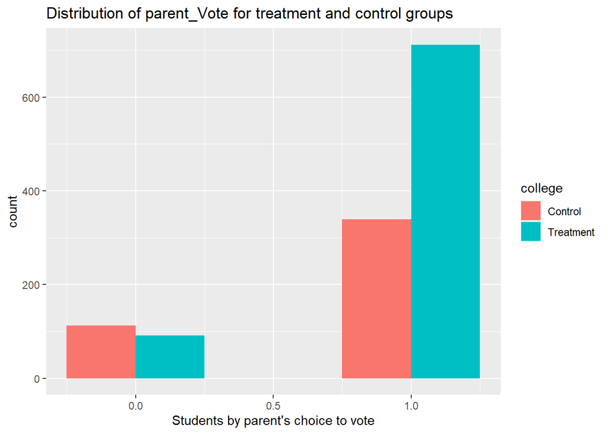

```r
#We explore the distribution of students by those whose parents voted
dat_sub = ypsps %>% select (college,parent_Vote) %>%
  mutate(random_treat = sample(0:1,nrow(ypsps), replace=T,prob=c(0.5,0.5)))%>%
  mutate (college=if_else(college==1,"Treatment","Control") )%>%
  mutate (random_treat=if_else(random_treat==1,"Random Treatment","Random Control") )

# Visualize the distribution by treatment/control (ggplot)
ggplot(dat_sub, aes(x=parent_Vote, fill=college)) +
    geom_histogram(binwidth=.5, position="dodge")+
  ggtitle("Distribution of parent_Vote for treatment and control groups") +
  xlab("Students by parent's choice to vote")
```

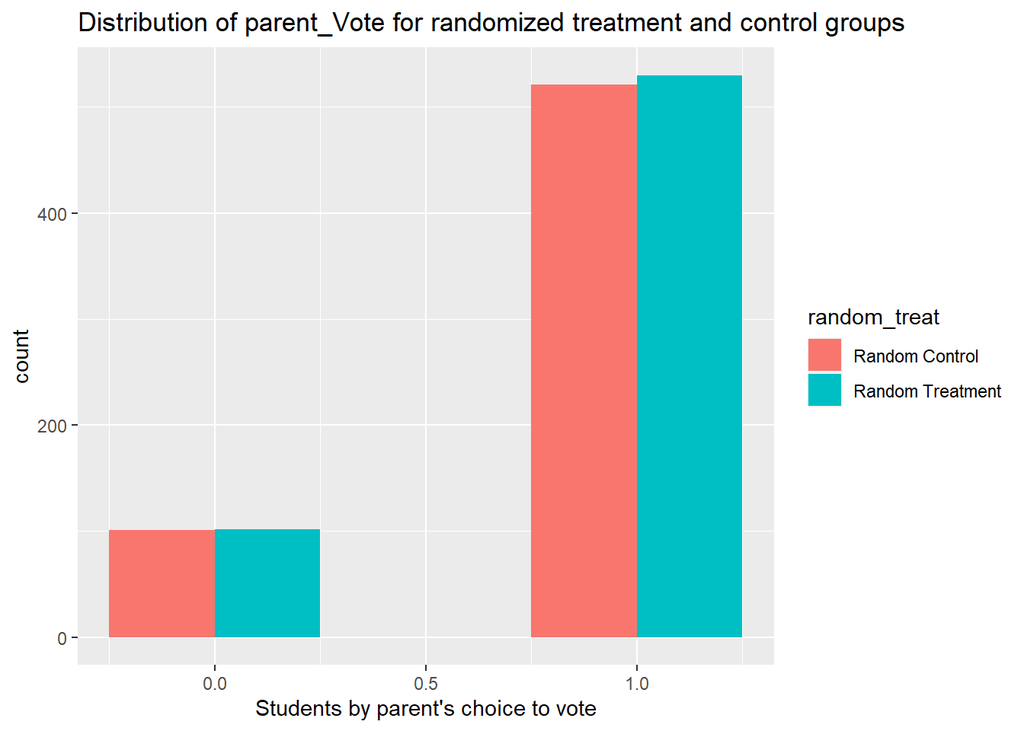

```r
# Visualize the distribution by random treatment/control (ggplot)
ggplot(dat_sub, aes(x=parent_Vote, fill=random_treat)) +
    geom_histogram(binwidth=.5, position="dodge")+
  ggtitle("Distribution of parent_Vote for randomized treatment and control groups") +
  xlab("Students by parent's choice to vote")
```

Simulate the first step 10,000 times and visualize the distribution of treatment/control balance across the simulations.

```r
# Simulate this 10,000 times (monte carlo simulation - see R Refresher for a hint)
sims=10000

#This function creates a randomized assignment to treatment with a 50/50 probability
#The outcome is a vector which counts the total number of people by treatment and covarriate value
rand_fun = function(){
  rand_vec =  sample(0:1,nrow(ypsps),rep=TRUE,prob=c(0.5,0.5))
  dat = ypsps%>% select(parent_Vote)%>%mutate(sim=rand_vec)
  result = data_frame(rand_sum = c(
  nrow(dat%>%filter(sim==0 & parent_Vote==0))
  ,nrow(dat%>%filter(sim==0 & parent_Vote==1))
  ,nrow(dat%>%filter(sim==1 & parent_Vote==0))
  ,nrow(dat%>%filter(sim==1 & parent_Vote==1))
  ))
  return(result)
}

#We replicate the process for the desired amount of simulations and calculate the mean
sim_result = rowMeans(bind_cols(replicate(sims,rand_fun())), na.rm = FALSE, dims = 1)
```

[output not shown]

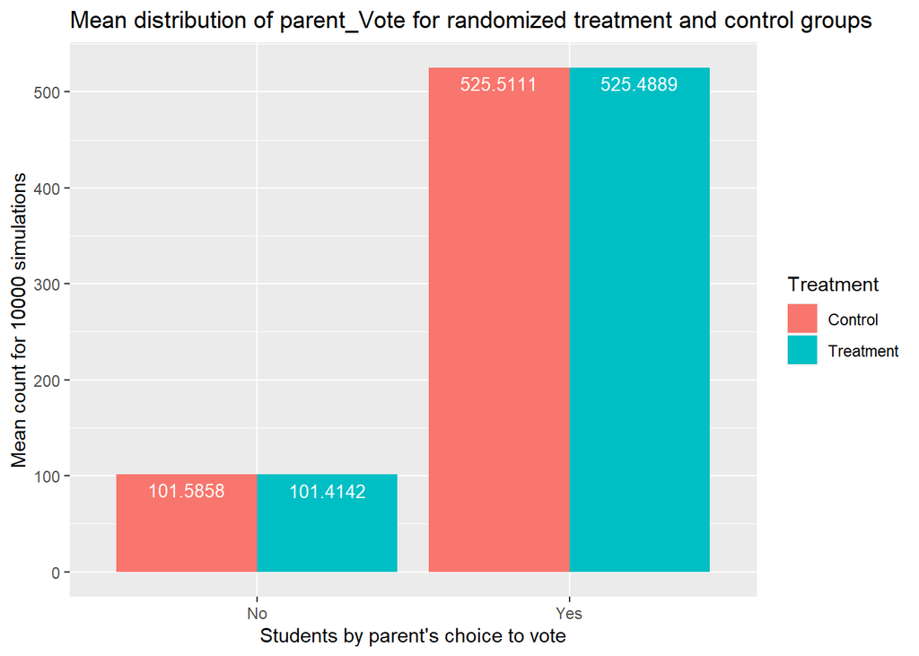

```r
#We store the mean values across all simulations in a table
sim_result_t = data_frame("Treatment"=c("Control","Control","Treatment","Treatment")
                          , "Parent_vote"=c("No","Yes","No","Yes")
                        ,"Mean"=c(sim_result[1],sim_result[2],sim_result[3],sim_result[4]))

#visualize
ggplot(data=sim_result_t, aes(x=Parent_vote, y=Mean, fill=Treatment)) +
geom_bar(stat="identity", position=position_dodge())+
  geom_text(aes(label=Mean), vjust=1.6, color="white",
            position = position_dodge(0.9), size=3.5)+
  ggtitle("Mean distribution of parent_Vote for randomized treatment and control groups") +
  xlab("Students by parent's choice to vote")+ ylab(paste0("Mean count for ",sims," simulations"))
```

## Questions

first draft: We see that the covariate we chose to explore - parent_vote - isn’t balanced for treatment and control. In the real expriment, the control group is underrepresented in the group of students whose parents voted. In randomized assignment, we would expect treatment and control to have similar distributions covarriates. This is a good example for how the independence of treatment assignment and baseline covariates does not guarantee balance of treatment assignment and baseline covariates. This imbalance raises concerns to whether this covariate and parhaps other covariates are confounders.

# Propensity Score Matching

## One Model

Select covariates that you think best represent the “true” model predicting whether a student chooses to attend college, and estimate a propensity score model to calculate the Average Treatment Effect on the Treated (ATT). Plot the balance of the top 10 (or fewer if you select fewer covariates). Report the balance of the p-scores across both the treatment and control groups, and using a threshold of standardized mean difference of p-score $\leq .1$, report the number of covariates that meet that balance threshold.

```r
# Select covariates that represent the "true" model for selection, fit model
ypsps_selected = ypsps %>% select(college,parent_Vote,parent_CivicOrg,parent_OwnHome
                                  ,parent_Rally,parent_PolClub,parent_Money
                                  ,student_AdultTalk,student_FrTalk
                                  ,student_Newspaper,student_Magazine
                                  ,student_Radio,student_FamTalk
                                  )

# Plot the balance for the top 10 covariates

#We write a function that selects the treatment variable (college) and one covariate at a time
#and calculates their mean and a chi-squered test of difference.
balance_fun = function(dat,n){
  dat_sub = dat%>% select(college,colnames(dat)[n])
  result = data_frame(covariate = as.character(colnames(dat)[n])
                      ,control = round(mean((dat_sub%>%filter(college==0)%>% select(-college))[,1]),3)
                     ,treatment = round(mean((dat_sub%>%filter(college==1)%>% select(-college))[,1]),3)
                     ,chisq_test = round(chisq.test(table(ypsps_selected$college,
                                                    ypsps_selected[,colnames(ypsps_selected)[n]]))$p.value,5)
                      )
  return(result)
}

datalist=list()
for (i in 2:ncol(ypsps_selected)){
 datalist[[i]] =balance_fun(ypsps_selected,i)
}
balance = bind_rows(datalist)

#Top ten variables by balance on covariates
head(arrange(balance,desc(chisq_test)), n = 10)
```

| covariate | control | treatment | chisq_test |
| --- | --- | --- | --- |
| student_Radio | 2.776 | 2.640 | 0.64477 |
| student_AdultTalk | 2.998 | 2.961 | 0.12962 |
| parent_PolClub | 0.040 | 0.086 | 0.00306 |
| parent_CivicOrg | 1.064 | 1.197 | 0.00028 |
| student_Newspaper | 2.233 | 1.943 | 0.00014 |
| student_FamTalk | 2.113 | 1.843 | 0.00004 |
| parent_OwnHome | 0.743 | 0.844 | 0.00002 |
| parent_Vote | 0.752 | 0.887 | 0.00000 |
| parent_Rally | 0.137 | 0.296 | 0.00000 |
| parent_Money | 0.102 | 0.288 | 0.00000 |

Report the overall balance and the proportion of covariates that meet the balance threshold

```r
# Report the overall balance and the proportion of covariates that meet the balance threshold
balance
```

| covariate | control | treatment | chisq_test |
| --- | --- | --- | --- |
| parent_Vote | 0.752 | 0.887 | 0.00000 |
| parent_CivicOrg | 1.064 | 1.197 | 0.00028 |
| parent_OwnHome | 0.743 | 0.844 | 0.00002 |
| parent_Rally | 0.137 | 0.296 | 0.00000 |
| parent_PolClub | 0.040 | 0.086 | 0.00306 |
| parent_Money | 0.102 | 0.288 | 0.00000 |
| student_AdultTalk | 2.998 | 2.961 | 0.12962 |
| student_FrTalk | 2.417 | 1.994 | 0.00000 |
| student_Newspaper | 2.233 | 1.943 | 0.00014 |
| student_Magazine | 2.013 | 1.614 | 0.00000 |

[output cut: 2 more lines]

```r
#proportion of covariates that meet the threshold
round(nrow(balance%>%filter(chisq_test>0.1))/nrow(balance)*100,2)
```

```
## [1] 16.67
```

## Simulations

```r
# Remove post-treatment and outcome covariates
ypsps_pre_treat = ypsps%>%select(!matches("1973")& !matches("1982")
                                 & -c("student_ppnscal","college","student_vote"
                                     ,"student_meeting","student_button"
                                     ,"student_money","student_communicate"
                                     ,"student_demonstrate","student_community"
                                     ,"student_other","interviewid"))


# Randomly select 30 features
ypsps_pre_treat_selected = ypsps_pre_treat[, sample(ncol(ypsps_pre_treat), #randomize the selection of columns
                                                    sample(15:50, 1, replace=TRUE) #randomize the number of columns
                                                    )]

# Simulate random selection of features 10k+ times


# Fit p-score models and save ATTs, proportion of balanced covariates, and mean percent balance improvement

# model_ps <- glm(college ~ parent_Vote + parent_CivicOrg + parent_OwnHome
#                 ,family = binomial()
#                 ,data = ypsps_selected)
#
# dat <- ypsps_selected %>% mutate(prop_score = predict(model_ps))
#
# #subset dataset
# df_a0 <- dat %>% filter(college == 0)
# df_a1 <- dat %>% filter(college == 1)
#
# dist.prop.score <- function(x,y) { abs(x-y) }
#
# calculate.dist <- function(x, y, dist.method, xnames = df_a1$ID, ynames = df_a0$ID) {
#   dists <- apply(y, 1, function(j) {apply(x, 1, function(i) {dist.method(i,j)})})
#   rownames(dists) <- xnames
#   colnames(dists) <- ynames
#   return(dists)
# }
#
# dists_ps <- calculate.dist(as.matrix(df_a1[, "prop_score"]),
#                            as.matrix(df_a0[, "prop_score"]),
#                            dist.prop.score)
# as.data.frame(dists_ps)


# Plot ATT v. proportion

# 10 random covariate balance plots (hint try gridExtra)
# Note: ggplot objects are finnicky so ask for help if you're struggling to automatically create them; consider using functions!
```

# Matching Algorithm of Your Choice

## Simulate Alternative Model

Henderson/Chatfield propose using genetic matching to learn the best weights for Mahalanobis distance matching. Choose a matching algorithm other than the propensity score (you may use genetic matching if you wish, but it is also fine to use the greedy or optimal algorithms we covered in lab instead). Repeat the same steps as specified in Section 4.2 and answer the following questions:

```r
# Remove post-treatment covariates

# Randomly select features

# Simulate random selection of features 10k+ times

# Fit  models and save ATTs, proportion of balanced covariates, and mean percent balance improvement

# Plot ATT v. proportion

# 10 random covariate balance plots (hint try gridExtra)
# Note: ggplot objects are finnicky so ask for help if you're struggling to automatically create them; consider using functions!
```

```r
# Visualization for distributions of percent improvement
```

## Questions

Looking ahead to the discussion questions, you may choose to model the propensity score using an algorithm other than logistic regression and perform these simulations again, if you wish to explore the second discussion question further.